# Drug Trends across Wisconsin: Report

Bureau of Justice Information and Analysis (BJIA)

6/10/2021

# Temporal Trends in Overdose Fatalities

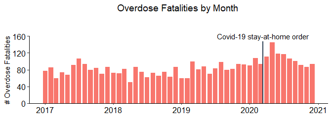

**Overdose Fatalities by Substance Involved**

An analysis was done to identify substances involved in overdose fatalities of Wisconsin residents, either alone or in combination. For all overdose fatalities, substances were grouped into the following categories based on terms contained in the immediate or contributing cause of death. Terms included both generic and brand names of substances:

- Fentanyl (includes fentanyl analogs)
- Heroin
- Other opioid (includes illicit and prescription substances such as codeine, morphine, hydrocodone, hydromorphone, tramadol. Fentanyl is not included)
- Cocaine
- Methamphetamine
- Gabapentin
- Benzodiazepine (includes substances such as alprazolam, diazepam, cloneazepam, and temazepam)

These substances are not mutually exclusive, as one fatality can be attributed to an overdose of multiple substances.

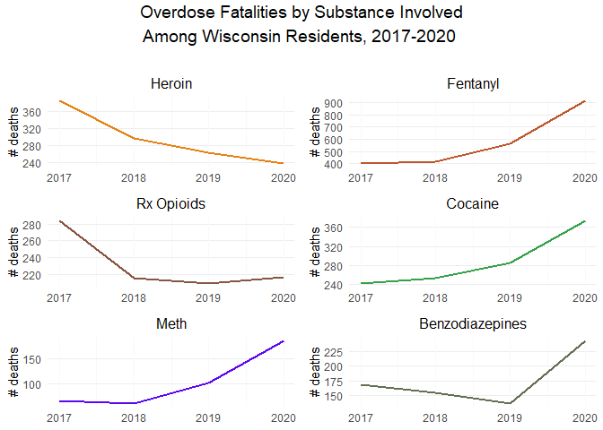

# Spatial Trends in Overdose Fatalities

**Overdose Fatalities by Substance Involved**

This analysis looked at how overdose fatalities varied over time and space, and by type of substance involved. For this analysis, the the same substance categorizations were used:

- Fentanyl (includes fentanyl analogs)
- Heroin
- Other opioid (includes illicit and prescription substances such as codeine, morphine, hydrocodone, hydromorphone, tramadol. Fentanyl is not included)
- Cocaine
- Methamphetamine
- Gabapentin
- Benzodiazepine (includes substances such as alprazolam, diazepam, cloneazepam, and temazepam)

These substances are not mutually exclusive, as one fatality can be attributed to an overdose of multiple substances.

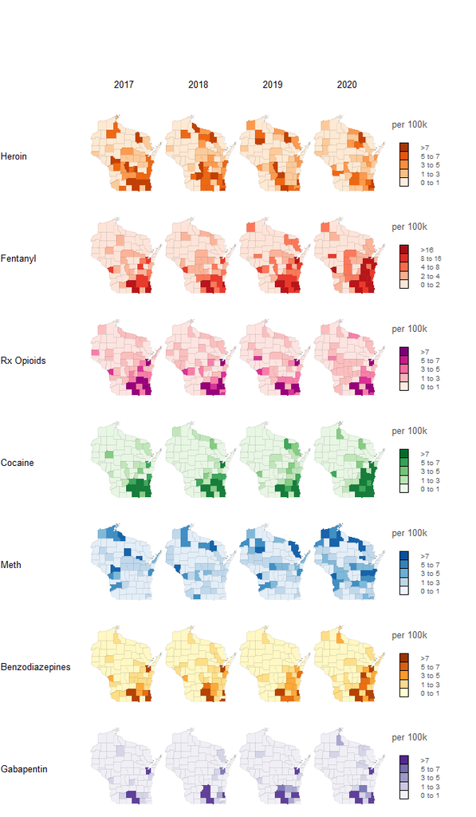

# Substances Identified in Overdose Fatalities

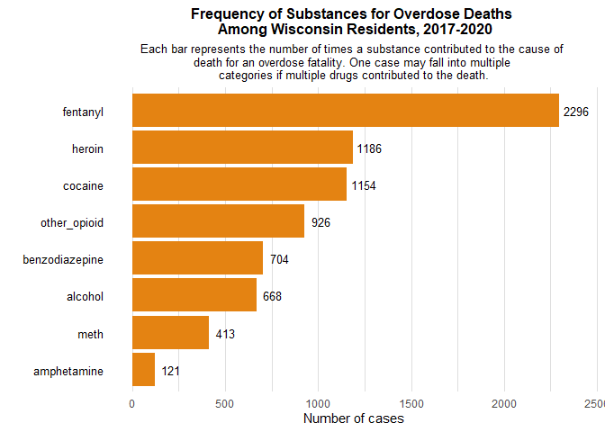

**Overdose Fatalities by Type (Single or Multi-Drug)**

| Type of Case | N cases |
| --- | --- |
| Multiple Drugs | 2432 |
| Single Drug | 1319 |

### Substance Combinations in Overdose Fatalities

An analysis was done to identify drug combinations in overdose fatalities. For all overdose fatalities, substances were grouped into the following categories based on terms contained in the immediate or contributing cause of death. Terms included both generic and brand names of substances:

- Fentanyl (includes fentanyl analogs)
- Heroin
- Other opioid (includes illicit and prescription substances such as codeine, morphine, hydrocodone, hydromorphone, tramadol)
- Cocaine
- Methamphetamine
- Amphetamine
- Benzodiazepine (includes substances such as alprazolam, diazepam, cloneazepam, and temazepam)
- Alcohol

| Substance 1 | Substance 2 | N cases | % of All Deaths |
| --- | --- | --- | --- |
| fentanyl | cocaine | 666 | 17.755265 |
| fentanyl | heroin | 646 | 17.222074 |
| fentanyl | alcohol | 419 | 11.170355 |
| fentanyl | other_opioid | 407 | 10.850440 |
| fentanyl | benzodiazepine | 402 | 10.717142 |
| heroin | cocaine | 353 | 9.410824 |
| cocaine | alcohol | 242 | 6.451613 |
| other_opioid | benzodiazepine | 241 | 6.424953 |
| fentanyl | meth | 228 | 6.078379 |
| heroin | benzodiazepine | 227 | 6.051719 |

### Substance Combinations Visualized

Each line represents a potential pairing of substances that was involved in an overdose fatality. The thickness and color of the lines indicate the percentage of all cases (single or multiple drug) in which that substance combination was present, as indicated on the death certificate. In fatalities in which more than two substances were involved, the substances were divided into unique combinations of two.

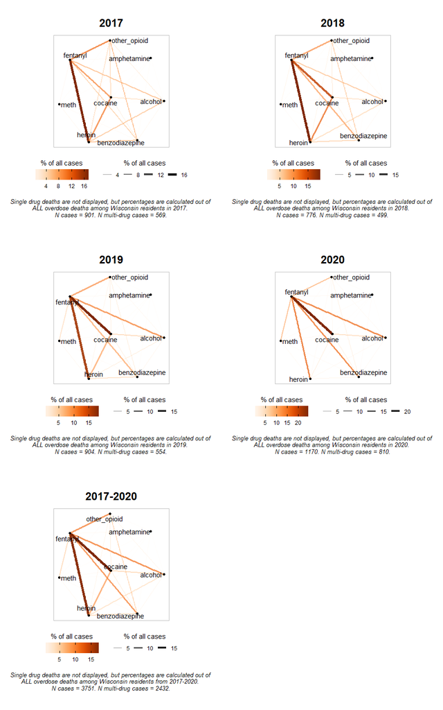

# The Rural Urban Divide in Wisconsin

Trends in overdose fatalities vary over geographic space. Wisconsin counties were coded as urban or rural using Rural-Urban Continuum Codes from the Economic Research Service (ERS). ERS categorizes counties as Metro Counties (counties in a metropolitan statistical area), Non-Metro Counties - Urban Population greater than 25,000, and Non-Metro Counties - Urban Population less than 25,000.

For this analysis, all Metro Counties were defined as “urban”, while Non-Metro Counties were defined as “rural”.

For more information on Rural-Urban Continuum Codes, see http://www.rwhc.com/mediasite/5-App-Kures,%20Matt_%20Plenary_am_Demographics.pdf

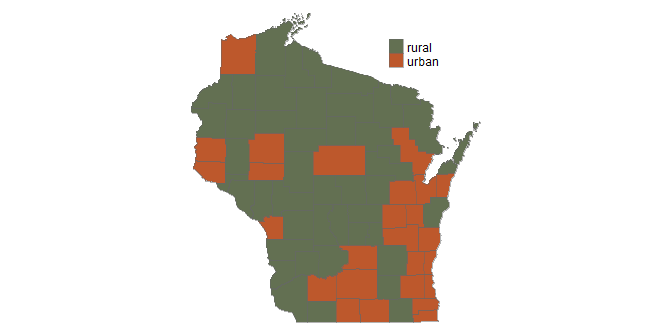

**The fatal overdose rate per 100,000 people (2017-2020) is 19.1 for urban counties and 9.3 for rural counties.**

### Substances Identified in Overdose Fatalities: Urban vs. Rural

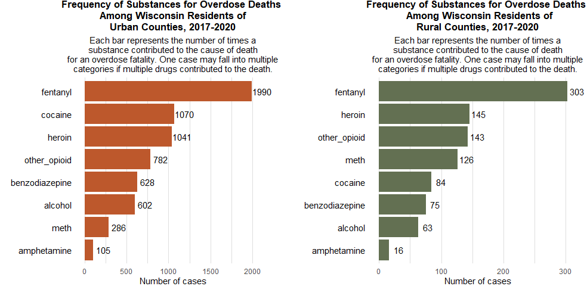

### Drug combinations: Urban vs. Rural

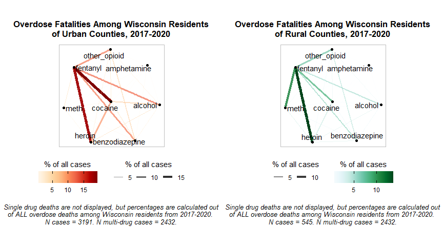

# Spatial Trends in Wisconsin Crime Lab Drug Cases

This analysis of Wisconsin Crime Lab drug cases identifies substances identified in each case. Each case can have multiple substances present at varying weights; this analysis only checks for the presence of specific substances, regardless of weight. For all crime lab cases from 2017 to 2020, substances were grouped into the following categories:

- Fentanyl (includes fentanyl analogs)
- Heroin
- Other opioid (includes illicit and prescription substances such as codeine, morphine, hydrocodone, hydromorphone, tramadol and excludes fentanyl)
- Cocaine
- Methamphetamine
- Benzodiazepine (includes substances such as alprazolam, diazepam, cloneazepam, and temazepam)
- Gabapentin

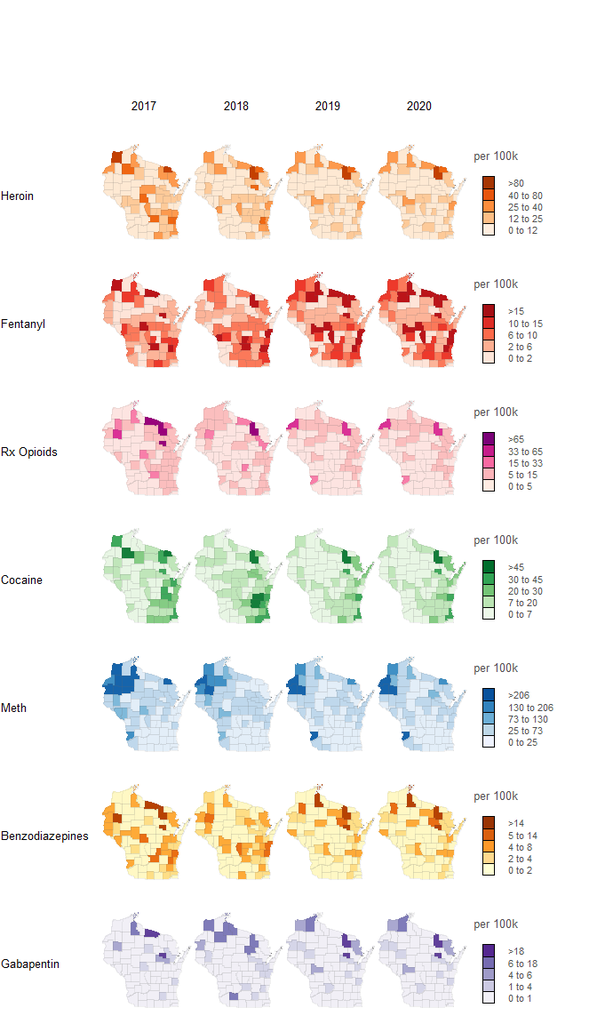

# Building an Explanatory Model for Overdose Fatalities at the County-Level

There is significant county-wide variation in overdose fatalities. This analysis attempts to explore the relationship between overdose fatalities and various “predictor” variables at the county-level, from years 2017 to 2020. The following data was collected at the county-level:

## Variables and Definitions

| Variable Name | Source |
| --- | --- |
| Overdose Fatalities per capita | DHS |
| *Drug Seizures per capita | Incident-Based-Reporting (DOJ) |
| *Drugs Tested by Crime Lab per capita | Wisconsin Crime Lab (DOJ) |
| Total Doses of Controlled Substances per capita | Prescription Monitoring Drug Program (PDMP) |
| % in Poverty | US Census |
| Gini Index (measure of wealth inequality) | US Census |
| % on Supplemental Income | US Census |
| % Unemployed | US Census |
| % with less than a college degree | US Census |
| % Black | US Census |
| % White | US Census |
| % Hispanic | US Census |
| % Asian | US Census |
| % American Indian or Alaska Native | US Census |
| % Hawaiian Islander | US Census |
| % Single-Parent Households | US Census |
| % Vacant Housing Units | US Census |
| % with a Doctorate Degree | US Census |
| % without Health Insurance | US Census |
| Number of MDs per capita | Area Health Resource Files (AHRF) |
| Total Population from 2017 to 2019 (aggregated) | US Census |

In part, these variables were selected based on previous research that identified factors associated with county-level variation in fatal drug overdoses across the US (Monnat 2018). Monnat regressed overdose fatality rate on a number of predictor variables, including socio-economic, race, and heath data. Where possible, I included the same socio-economic and race/ethnicity predictors in my analysis.

Total drug seizures was calculated by noting whether an incident contained one of the following drugs:

- Crack Cocaine
- Cocaine
- Heroin
- Morphine
- Opium
- Other Narcotics
- PCP
- Amphetamines / Meth
- Other Stimulants
- Barbiturates

Incidents containing any one of these drugs was flagged and then aggregated to the county-level.

Drugs Tested by Crime Lab is an aggregate count of the number of positive identifications for the following drugs:

- Benzodiazepines
- Cocaine
- Gabapentin
- Heroin
- Hydrocodone
- Meth
- Rx Opioids
- Tramadol

Total Doses of Controlled Substances per Capita included prescriptions for the following drugs:

- Acetaminophen with Codeine
- Alprazolam
- Amphetamine - Dextroamphetamine
- Buprenorphine - Naloxone
- Clonazepam
- Diazepam
- Hydrocodone - Acetaminophen
- Lisdexamphetamine Dimesylate
- Lorazepam
- Methylphenidate Hcl
- Morphine Sulphate
- Oxycodone Hcl
- Oxycodone with Acetaminophen
- Pregabaline
- Tramadol Hcl
- Zolpidem Tartrate

## Bivariate Scatterplots

Bivariate scatterplots can be used to see the relationship between each predictor variable and fatal overdose rate.

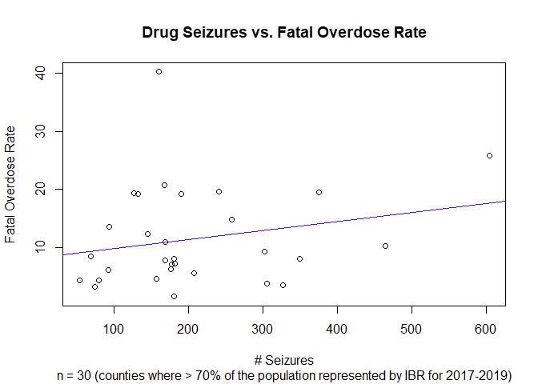

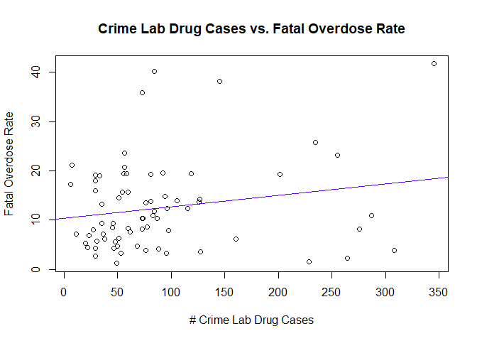

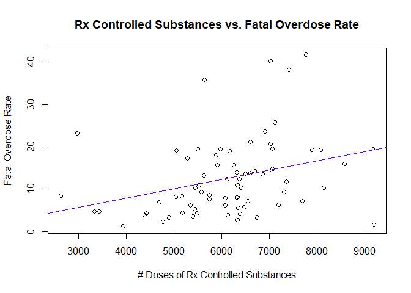

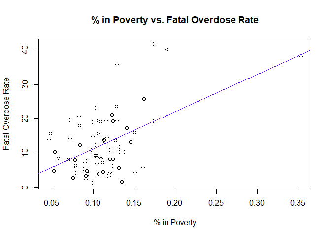

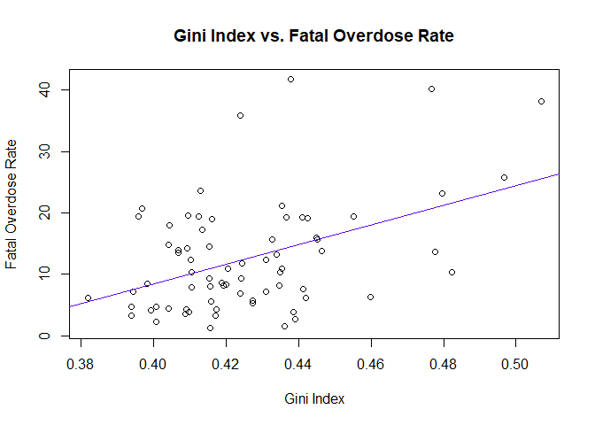

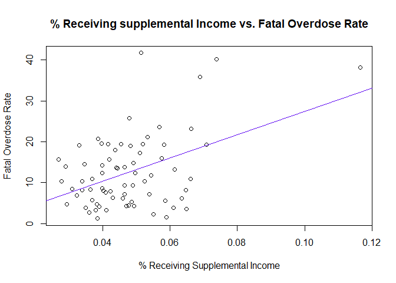

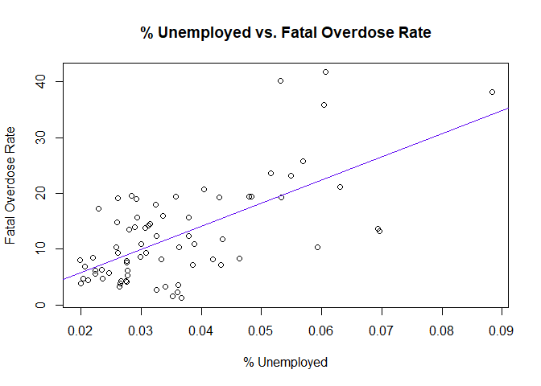

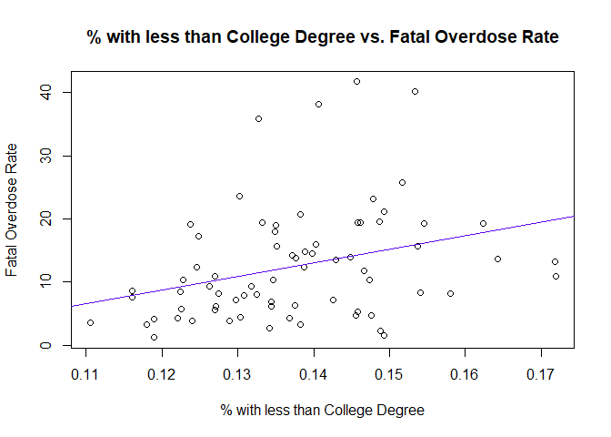

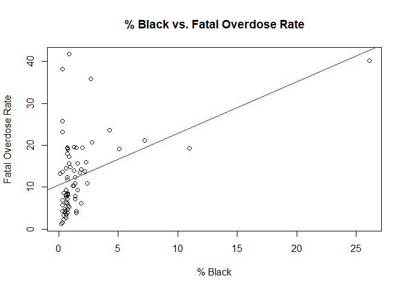

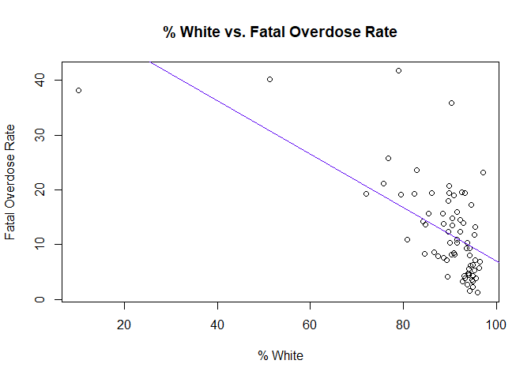

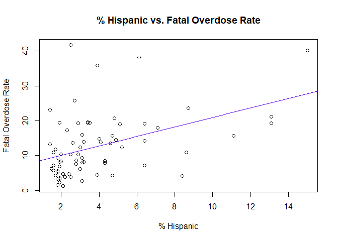

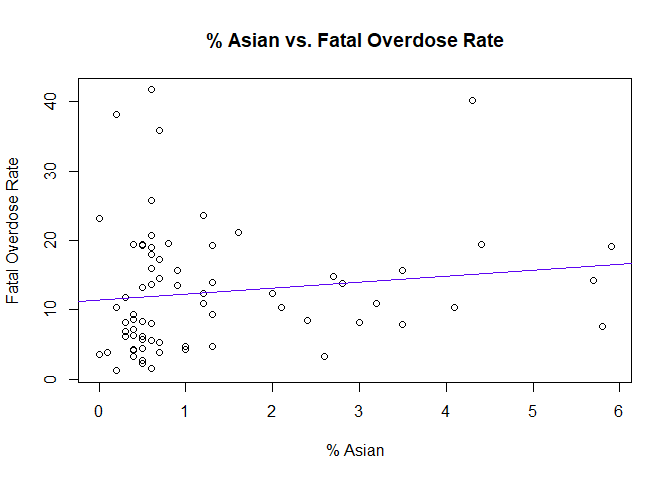

[8 more figures not shown]

## Preparation and Selection of Variables for Multiple Linear Regression Analysis

For linear regression analysis, drug seizure data was ommitted due to missing data (many counties had no IBR submissions for this time period). % Hawaiian Islander was also excluded due to very low percentages of this population in Wisconsin counties.

With the exception of Total Doses of Controlled Substances per Capita, all variables were non-normally distributed so log and square root transformations were applied.

```
##
## Call:
## imcdiag(mod = linearMod_all_predictors, method = "VIF", vif = 5)
##
##
##  VIF Multicollinearity Diagnostics
##
##                                             VIF detection
## log(pov_perc)                            7.2563         1
## log(supp_inc_perc)                       4.0725         0
## log(unemply_perc)                        3.3385         0
## log(gini_index)                          2.6569         0
## log(somecollg_less_perc)                 1.6320         0
## sqrt(doctorate_perc)                     3.6237         0
## log(no_health_ins_perc)                  4.6238         0
## log(black_perc)                          3.0577         0
## log10(max(white_perc + 1) - white_perc) 16.7284         1
## log(hispanic_perc)                       6.7339         1
## sqrt(asian_perc)                         4.8796         0
## log(amerInd_AKnat_perc)                  7.7743         1
## log(sing_parent_hh_perc)                 4.5412         0
## log(vac_housing_units_perc)              5.9966         1
## log(md_per_100k)                         2.9283         0
## log(crime_lab_total_per_cap)             1.6268         0
## total_doses_per_cap                      1.7267         0
## log(pop_2017to2019)                      7.7119         1
##
## Multicollinearity may be due to log(pov_perc) log10(max(white_perc + 1) - white_perc) log(hispanic_perc) log(amerInd_AKnat_perc) log(vac_housing_units_perc) log(pop_2017to2019) regressors
##
## 1 --> COLLINEARITY is detected by the test
## 0 --> COLLINEARITY is not detected by the test
##
## ===================================
```

Multi-collinearity diagnostics indicated the presence of multi-collinearity. Variance Inflation Factor (VIF) was used to detect multi-collinearity; any variable with a VIF value greater than 5 was removed from the model. Variables were removed one-by-one, beginning with the variable with the highest VIF value (white_perc). Variables were subsequently removed based on VIF value until all variables had a VIF value of 5 or less. This produced the following list:

```
##
## Call:
## imcdiag(mod = linearMod_subset, method = "VIF", vif = 5)
##
##
##  VIF Multicollinearity Diagnostics
##
##                                 VIF detection
## log(supp_inc_perc)           2.3554         0
## log(unemply_perc)            2.2943         0
## log(gini_index)              1.6529         0
## log(somecollg_less_perc)     1.5252         0
## sqrt(doctorate_perc)         2.5826         0
## log(no_health_ins_perc)      1.7199         0
## log(black_perc)              2.2803         0
## log(hispanic_perc)           1.9985         0
## sqrt(asian_perc)             2.1589         0
## log(amerInd_AKnat_perc)      1.7983         0
## log(crime_lab_total_per_cap) 1.4578         0
##
## NOTE:  VIF Method Failed to detect multicollinearity
##
##
## 0 --> COLLINEARITY is not detected by the test
##
## ===================================
```

This list of candidate variables was then tested using R’s olsrr package to determine which variable subset produced the best values for R-Squared and Adjusted R-Squared. The following predictors were chosen and used in multiple linear regression. % Unemployed, % with a Doctorate, and % Black were statistically significant predictors of logged fatal overdose rates.

|  | log(od per cap) |  |  |
| --- | --- | --- | --- |
| Predictors | Estimates | CI | p |
| (Intercept) | 10.00 | 5.66 – 14.35 | **<0.001** |
| supp_inc_perc [log] | -0.29 | -1.05 – 0.47 | 0.444 |
| unemply_perc [log] | 0.72 | 0.15 – 1.29 | **0.015** |
| gini_index [log] | 2.78 | -0.17 – 5.73 | 0.064 |
| somecollg_less_perc [log] | 1.41 | -0.29 – 3.11 | 0.103 |
| doctorate_perc [sqrt] | -7.57 | -15.01 – -0.13 | **0.046** |
| no_health_ins_perc [log] | -0.13 | -0.58 – 0.31 | 0.552 |
| black_perc [log] | 0.26 | 0.05 – 0.47 | **0.018** |
| hispanic_perc [log] | 0.20 | -0.11 – 0.51 | 0.210 |
| asian_perc [sqrt] | 0.23 | -0.12 – 0.58 | 0.187 |
| amerInd_AKnat_perc [log] | 0.06 | -0.07 – 0.19 | 0.376 |
| crime_lab_total_per_cap [log] | -0.14 | -0.33 – 0.05 | 0.152 |
| Observations | 72 |  |  |
| R<sup>2</sup> / R<sup>2</sup> adjusted | 0.553 / 0.471 |  |  |

# Assessing the Model

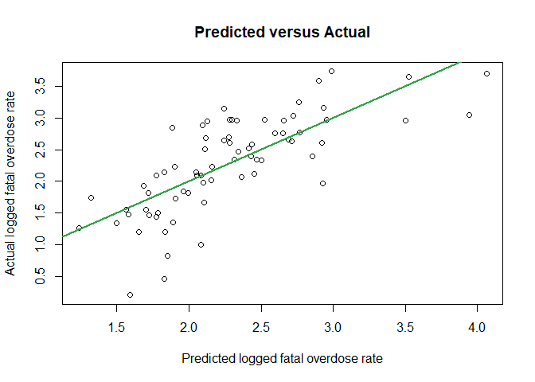

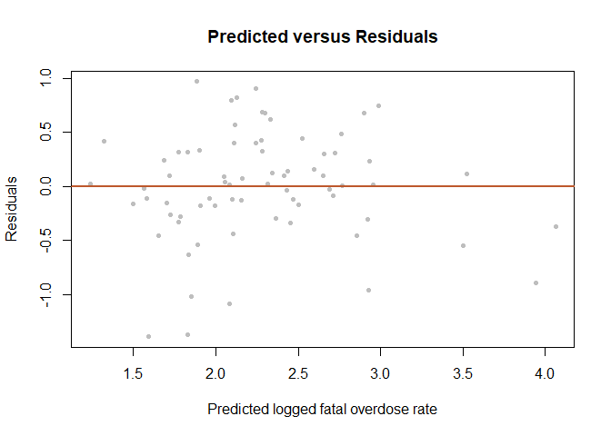